# tmppvqx7z5j

## 思想剧场：小敏的“烦恼侦探所”

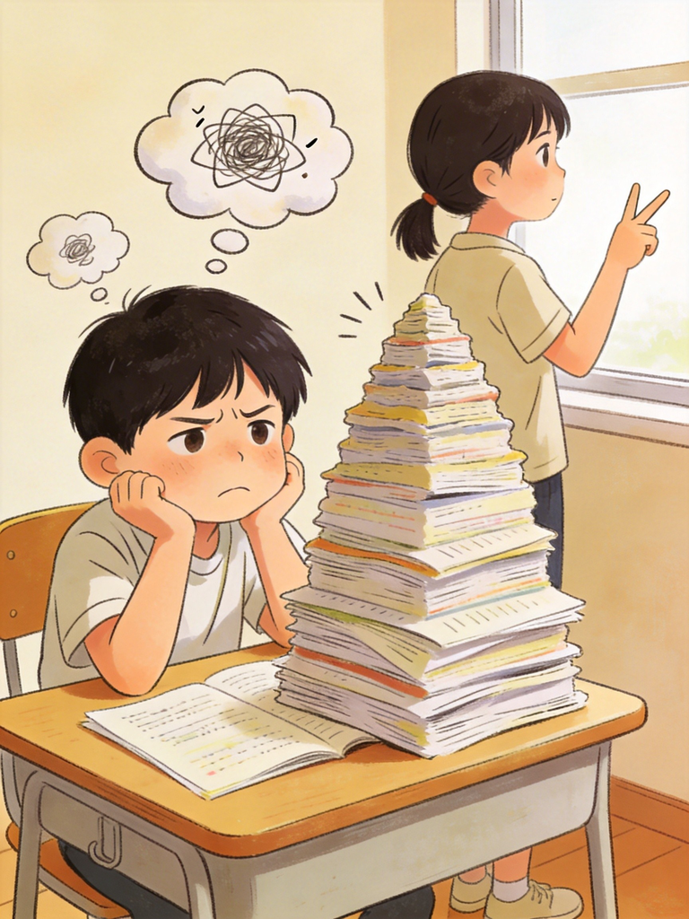

## 第一站：烦恼的“贴标签”工厂

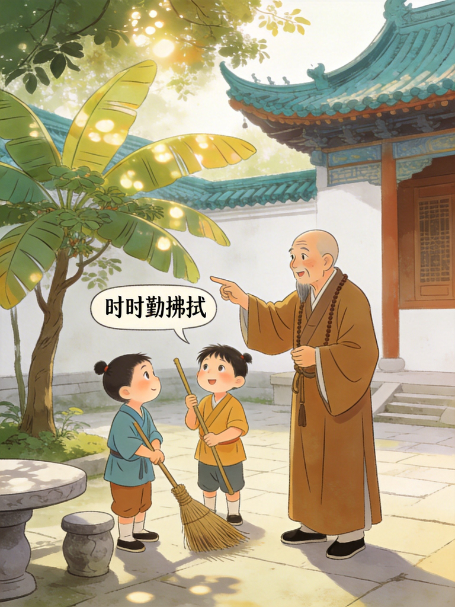

## 禅宗故事时间：慧能的传奇

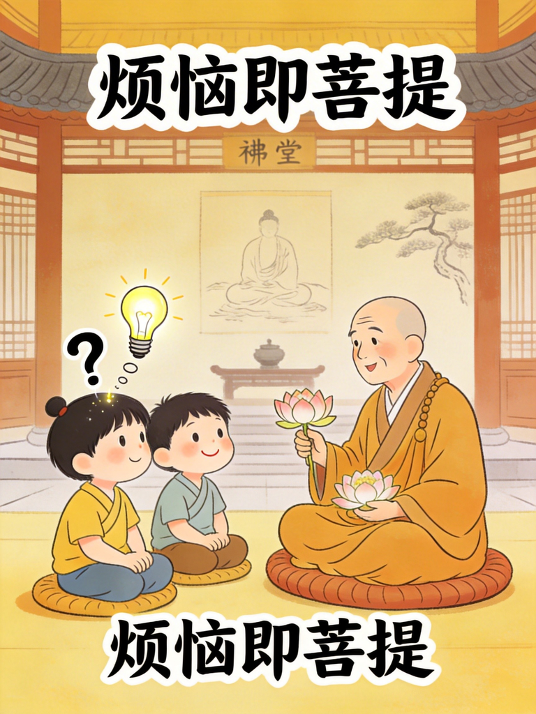

## 第三站：禅宗的智慧工具

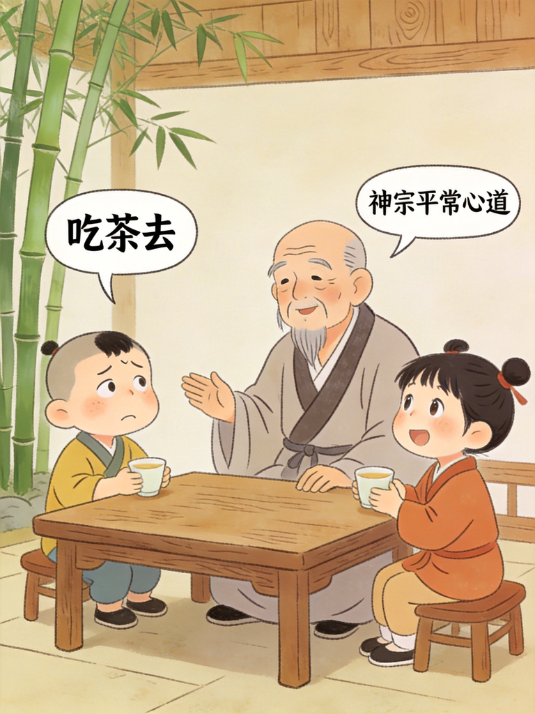

# 第八章 烦恼是怎么来的？

**时间**：周四下午放学后  
**地点**：学校心理辅导室（临时设立的“烦恼侦探所”）  
**人物**：小敏（11岁，数学烦恼）、小刚（爱打篮球，最近和队友闹矛盾）、小雨（敏感，总担心别人不喜欢自己）、心理老师王老师、慧能（穿越而来的禅宗六祖） （幕起） 心理辅导室被布置成“烦恼侦探所”，墙上贴着“烦恼线索板”。四个孩子围坐一圈，王老师在白板前。

**王老师**：（微笑）欢迎来到烦恼侦探所！今天的任务是：找出烦恼的“真凶”。请大家说出最近最困扰你的一件事。

**小敏**：（举手）我先来！我最烦恼数学考试。昨天又考了75分，同桌小玲又是100分。我觉得自己好笨，永远赶不上她。

**小刚**：我也有烦恼！我们篮球队队长总偏心，把上场机会都给他朋友。我跟他说了几次，他根本不理我。

**小雨**：（小声）我……我总是担心小组讨论时说错话，同学会觉得我笨。每次发言前都要想好久，越来越不敢说话了。 （忽然，窗外飘来一阵淡淡的檀香。一位穿着简朴僧衣、手持竹杖的和尚缓步走进，正是慧能。）

**慧能**：（合十微笑）各位小侦探，贫僧慧能，听说你们在找烦恼的“真凶”？不如让贫僧也加入？

**小敏**：（惊讶）您就是写“菩提本无树”的那位慧能大师？您真的能帮我们吗？

**慧能**：试试看。不过，先问你们几个问题。 — ### 儿童提问环节（≥5次主动提问）

**小敏**：（好奇）大师，为什么我看到小玲考满分就那么难受？明明她也没惹我。

**慧能**：好问题。这叫“分别心”。你把“她”和“我”分开，又把“好”和“坏”贴上去。

**小刚**：（质疑）等等，比赛不就是分输赢吗？不分怎么知道谁打得好？

**慧能**：分别本身没错，但

**执著于分别**就会烦恼。比如，你执著于“队长必须公平”，可他能完全公平吗？ **小雨**：（小声）那……我怎么才能不怕说错话？

**慧能**：先问：你怕的究竟是“说错话”，还是“别人觉得我笨”？

**慧能**：所以，你怕的是

**自己贴的标签**被确认。 **小刚**：（质疑）这不就是自我安慰吗？烦恼来了，告诉自己“别在意”就行？

**慧能**：（摇头）不是“别在意”，是

**看清楚它是什么**。烦恼像乌云，你当成整个天空；看清楚了，它只是飘过的云。 **小雨**：（提问）可是云来了，天就阴了呀。烦恼来了，心情就坏了。

**慧能**：天空会被云遮住，但天空本身没变。你的觉察力就是天空，烦恼只是暂时的天气。

**小刚**：（疑惑）可是大师，如果天空一直不变，那为什么我们还会感觉到阴天呢？烦恼来了就是难受啊！

**慧能**：问得好！阴天是感受，天空是觉察。你可以同时拥有“难受的感受”和“知道自己正在难受的觉察”。就像你可以一边牙疼，一边知道“哦，我在牙疼”。

**小敏**：（立场选择）那我选……试着看清烦恼，不跟它跑！可是，怎么做呢？

**慧能**：好，我们一步步来。 — ### 🌟 核心概念：分别心  
（来自《哲学儿童词典》补充词条） - **哲人术语**：分别心  
- **儿童比喻**：**给万事万物贴标签的机器**。自动把世界分成“好/坏”“对/错”“我/他”“聪明/笨”。  
- **生活案例**：看到同学穿名牌鞋，心里自动贴上“他家有钱”的标签；看到自己穿普通鞋，贴上“我穷”的标签——其实鞋子舒服才最重要。  
- **一句话记住**：分别心是烦恼的打印机，标签贴得越多，烦恼越多。 ### 思想剧场延伸：神秀vs慧能的“打扫”辩论

**场景**：侦探所白板上出现两个动画小人——神秀和慧能。

**神秀**：（认真扫地）身是菩提树，心如明镜台，时时勤拂拭，勿使惹尘埃。

**小敏**：我懂了！心里有灰尘（烦恼）要经常打扫。

**小雨**：（点头）我也有这种感觉！每次我练钢琴练不好时，心里就像蒙了一层灰，越着急越弹不好。

**慧能**：正是！灰尘来了，你知道它是灰尘，就不会把它当成整个房间。

**慧能**：（轻松舂米）菩提本无树，明镜亦非台，本来无一物，何处惹尘埃。

**小刚**：（困惑）你俩到底谁对？一个说要扫，一个说没灰尘可扫。

**慧能**：都对，但适合不同阶段。  
- 神秀的方法：初学阶段，承认烦恼存在，每天练习“觉察+清理”。  
- 慧能的方法：进阶阶段，看清烦恼本质是“空”，连清理的动作都不需要。 **小雨**：（提问）那我该用哪种？

**慧能**：从神秀开始。就像学骑车，先装辅助轮（勤拂拭），熟练了再拆掉（本来无一物）。 — 慧能（638年—713年），禅宗第六祖，他的故事像一部冒险电影。

**早年生活**：慧能小时候家里穷，每天砍柴卖钱养家。有一天在集市听到《金刚经》“应无所住而生其心”，心里一亮。

**求法经历**：24岁时去湖北黄梅拜五祖弘忍为师。弘忍看他是个不识字的樵夫，问他来求什么，慧能答：“只求成佛。”弘忍问：“你这蛮子也想成佛？”慧能反问：“人有南北，佛性也有南北吗？”弘忍知道此人根器不凡。

**寺院修行**：弘忍让慧能在厨房舂米八个月，他每天边舂米边思考“佛性是什么”，明白佛性就在每个人心里。

**继承衣钵**：弘忍要选接班人，让大家写偈子。神秀写：“身是菩提树，心如明镜台，时时勤拂拭，勿使惹尘埃。”慧能不识字，请人代写：“菩提本无树，明镜亦非台，本来无一物，何处惹尘埃。”弘忍知道慧能已悟到“空”的境界，半夜传他衣钵，让他南逃隐居十五年。

**开坛说法**：后来慧能在广东曹溪开坛说法，创立“顿悟”禅法，强调“不立文字，直指人心”。他的语录被编成《六祖坛经》。

**给探险家的问题**： > 1. 慧能从砍柴少年到禅宗祖师，你觉得他最重要的品质是什么？ > 2. 如果让你用一句话向朋友介绍慧能，你会怎么说？ — 禅宗给了我们四个特别有用的“心灵工具”，就像探险家的多功能刀。学会使用它们，烦恼来时你就能从容应对。

### 工具一：🌟顿悟（灵光一闪） - **儿童比喻**：**突然亮起的灯泡**。黑暗中摸索很久，一下找到开关，整个房间都亮了。 - **生活案例**：数学题想了三天都没解出来，洗澡时突然冒出解法——“啊哈！”这就是顿悟。 -

**小练习**：每天找一个“卡住”的问题（比如作文开头），先不想它，去散步/听音乐，记录灵感何时出现。 ### 工具二：🌟渐悟（每天进步一点点） -

**儿童比喻**：**小树苗长成大树**。不是一夜长高，而是每天吸收阳光雨水，不知不觉枝繁叶茂。 - **生活案例**：每天练10分钟口算，一个月后速度翻倍——你没感觉“顿悟”，但确实进步了。 -

**小练习**：选一个想提升的技能（如跳绳），每天记录微小进步（多跳1个、更稳一点），画成成长曲线。 ### 工具三：🌟无念为宗（心里不留烦恼垃圾） -

**儿童比喻**：**水流过不留痕**。烦恼像落叶掉进溪流，让它自然漂走，不在心里堆积。 - **生活案例**：被老师批评后，心里反复想“我是不是很差”→练习“念头只是念头”，想象批评的话像落叶漂走。 -

**小练习**：烦恼时写纸条，折成纸船放进水里（或丢垃圾桶），说：“你只是念头，我不留你。” ### 工具四：🌟烦恼即菩提（乌云和天空是一体的） -

**儿童比喻**：**乌云背后是蓝天**。乌云（烦恼）来了，你知道它只是暂时的，蓝天（智慧）一直在。 - **生活案例**：考试失败很烦恼，但正是这次失败让你发现“我需要改变学习方法”——烦恼变成了智慧。 -

**小练习**：每次烦恼后问：“这件事教会了我什么？”写下三个收获。

**综合练习：制作你的“禅宗工具卡”** 1. 拿四张卡片，分别画代表四个工具的图案（灯泡、树苗、溪流、乌云+太阳）。 2. 背面写“儿童比喻”和“一句话记住”。 3. 当烦恼来，抽一张卡，用上面的方法应对。 4. 周末和家人分享：这周哪种工具最有用？ — ## 全球望远镜：禅宗与西方智慧的对话

### 第一组对比：顿悟 vs 柏拉图“回忆说” | 对比点 | 禅宗（顿悟） | 柏拉图（回忆说） | 差异说明 | 思考题 | |——–|————–|——————|———–|———-| | 核心比喻 | **灵光一闪**，像灯泡突然亮起 | **知识本来就在心里**，像遗忘的宝藏被记起 | 禅宗强调瞬间突破、不依赖学习；柏拉图认为学习是回忆先天知识 | 如果知识本来就在心里，为什么我们还要上学？ | | 获得方式 | 放下思维，直接体验 | 通过理性思考、对话引导回忆 | 禅宗“不立文字”，超越逻辑；柏拉图重视逻辑推理 | 你更相信“突然想通”还是“一步步推导”？ | | 儿童案例 | 苦思数学题，突然看懂解法 | 学几何时，觉得“这公式好像本来就该这样” | 顿悟常有“啊哈！”时刻；回忆说更像“似曾相识”感 | 你经历过“啊哈！”时刻吗？当时在做什么？ | **视觉建议**：  
【简笔画构思】：左边画灯泡突然发光（顿悟），右边画脑海中的宝藏箱打开（回忆说），中间用问号连接。 ### 第二组对比：无念为宗 vs 斯多葛学派“情绪控制” | 对比点 | 禅宗（无念为宗） | 斯多葛学派（情绪控制） | 差异说明 | 思考题 | |——–|——————|————————|———–|———-| | 核心比喻 | **心里不留烦恼垃圾**，像水流过不留痕 | **区分你能控制的和不能的**，像园丁只浇自己的花 | 禅宗注重内在觉察、不执著念头；斯多葛注重理性分析、主动选择 | 烦恼来了，你更想“看清它”还是“分析它”？ | | 操作方法 | 观察念头，不跟随，回到呼吸 | 列出“可控清单”和“不可控清单”，专注前者 | 禅宗是觉察练习；斯多葛是认知练习 | 如果你的烦恼是“同学不喜欢我”，哪些可控？哪些不可控？ | | 儿童案例 | 被嘲笑后，心里反复想“他们讨厌我”→练习“念头只是念头” | 比赛前紧张，写清单：可控（准备、心态）/不可控（对手、裁判） | 无念为宗减少内耗；情绪控制提升行动力 | 哪种方法对你更有用？为什么？ | **视觉建议**：  
【简笔画构思】：左边画溪流和落叶（烦恼流过），右边画园丁浇花（专注可控），中间用桥梁连接。 — ## 儿童创作角：我的禅宗偈子 禅宗祖师用偈子（四句诗）表达智慧。现在，轮到你了！为你最烦恼的事创作一个偈子，把烦恼变成诗歌。 ### 创作模板 **前两句：说出烦恼**  
（用比喻描述烦恼是什么）  
示例：数学难题像迷宫，我在里面转呀转。 **后两句：写出转化**  
（用比喻说明如何超越烦恼）  
示例：突然灵光一闪亮，原来出口在心中。 ### 进阶技巧 1. **对比法**：前两句“乌云”，后两句“蓝天”。  
- 例：批评话语像暴雨，过后彩虹挂天边。 2. **问答法**：前两句问，后两句答。  
- 例：为什么我总害怕？怕云飘过天空大。 3. **行动法**：前两句问题，后两句行动。  
- 例：作业堆积像小山，每天搬走一点点。 ### 作品展示区 **小敏的偈子**（数学烦恼）  
> 数学试卷像天书，  
> 看不懂呀心里苦。  
> 突然看懂一题解，  
> 原来我也可以酷！ **小刚的偈子**（队友矛盾）  
> 队长偏心不给球，  
> 我心里头真难受。  
> 换个角度想一想，  
> 我练技术更自由。 **小雨的偈子**（害怕发言）  
> 小组讨论不敢说，  
> 怕说错了被笑话。  
> 深吸一口气站起，  
> 声音虽小也是花。 ### 你的创作空间 1. **选一个烦恼**：________________________________ 2.

**前两句（比喻烦恼）**：  
________________________________________________ 3. **后两句（比喻转化）**：  
________________________________________________ 4. **给偈子起个名字**：____________________________

**分享挑战**：把偈子读给家人/朋友听，或贴在“烦恼侦探所”墙上。你会发现，当烦恼变成诗歌，它就没那么可怕了。 — ## 实践环节：三周“心灵扫除实验”计划 ### 设计理念 -

**目标**：通过每日15分钟的可操作任务，培养“看见烦恼不跟随”的能力。 -

**双版本**：亲子合作版（需要家长引导）和独立完成版（孩子自主进行）。 -

**记录表格**：配套“烦恼转化日志”，可视化进步轨迹。 ### 第一周：觉察烦恼（基础训练） | 日期 | 亲子合作版任务 | 独立完成版任务 | 记录要点 | |——|—————-|—————-|———–| | 周一 |

**情绪天气预报**：晚饭后，全家轮流说“今天的心情像什么天气”，不评判 |

**心情日记**：画或写一句话描述今天主要情绪 | 记录情绪类型 | | 周二 |

**标签拆解游戏**：选一个烦恼，家长问“你贴了什么标签？”，孩子回答并改写 |

**标签改写练习**：把“我很笨”改成“我有一个‘笨’的想法” | 记录标签改写 | | 周三 |

**呼吸锚点练习**：一起坐3分钟，专注呼吸，数到10重新开始 |

**3分钟呼吸空间**：找个安静角落，闭眼专注呼吸 | 记录分心次数 | | 周四 |

**烦恼分类**：把本周烦恼按“分别/执著/控制”分类，讨论 |

**烦恼侦探表**：填表分类自己的烦恼 | 识别烦恼类型 | | 周五 |

**分享会**：每人分享一个“看见烦恼没跟随”的小胜利 |

**胜利笔记**：写下一件“我做到了”的小事 | 积累成功体验 | | 周末 |

**家庭禅意时刻**：一起听自然声音（雨声、溪流），不说话 |

**自然观察**：观察一棵树/一片云15分钟，写感受 | 连接自然 | ### 第二周：转化烦恼（进阶训练） | 日期 | 亲子合作版任务 | 独立完成版任务 | 记录要点 | |——|—————-|—————-|———–| | 周一 |

**念头命名**：当烦恼出现，家长提醒“这是‘比较念头’”，孩子重复 |

**念头命名卡**：制作卡片，写上常见念头类型，抽卡匹配 | 熟悉念头类型 | | 周二 |

**智慧对话**：模拟慧能和小敏对话，家长扮演慧能，孩子提问 |

**自我对话练习**：写下烦恼，用慧能口吻回答自己 | 体验第三人视角 | | 周三 |

**控制权地图**：画圆圈，内圈“我能控制”，外圈“我不能” |

**可控清单**：列出当前烦恼中自己能控制的具体行动 | 聚焦行动 | | 周四 |

**身份剥离戏剧**：家长演“烦恼角色”（如“笨小敏”），孩子演“觉察者”指出 |

**身份纸条**：写烦恼身份贴纸上，然后撕掉 | 体验自我与念头分离 | | 周五 |

**偈子创作工坊**：全家一起为某个烦恼创作四句偈子 |

**我的烦恼偈**：选择最烦恼的事，创作偈子分享 | 创意表达情绪 | | 周末 |

**静心徒步**：去公园/山林，边走边练习“看见念头不跟随” |

**觉察散步**：散步15分钟，专注脚步和呼吸 | 动态中的静心 | ### 第三周：整合应用（生活实验） | 日期 | 亲子合作版任务 | 独立完成版任务 | 记录要点 | |——|—————-|—————-|———–| | 周一 |

**烦恼预警系统**：设计信号（如摸耳朵），家长发现孩子陷入烦恼时发出 |

**自我预警**：设定手机提醒“看见念头”，每天3次 | 建立觉察习惯 | | 周二 |

**情绪急救包**：共同制作“当我烦恼时可以做…”的清单（听歌、画画、呼吸） |

**我的急救包**：制作个人情绪调节工具卡 | 主动应对策略 | | 周三 |

**感恩扫描**：睡前轮流说三件今天感恩的事，包括“感谢烦恼让我学习” |

**感恩日记**：每天写下三件感恩事 | 培养积极视角 | | 周四 |

**家庭禅宗故事会**：分享本章慧能故事，讨论“如果是我会怎么做” |

**故事续写**：给慧能和小敏的故事写一个现代版结局 | 深化理解 | | 周五 |

**成果展示会**：展示三周的记录表格、偈子、急救包，庆祝进步 |

**个人展览**：整理三周材料，给自己办个小展览 | 看见成长 | | 周末 |

**结业仪式**：颁发自制“心灵扫除小专家”证书，计划持续练习 |

**自我认证**：设计并颁发自己的结业证书 | 肯定努力 | — ## 给家长的话：如何支持孩子的心灵扫除探险 作为家长，你的角色不是“解决”孩子的烦恼，而是成为他们探索内心的“安全基地”。以下是四个关键原则： ### 1. 从“解决问题”转向“陪伴觉察” -

**不要说**：“这有什么好烦的？别想了。” -

**可以说**：“听起来这件事让你很难受。你愿意和我一起看看这个‘烦恼’长什么样吗？” -

**原理**：孩子需要的是情绪被看见，而不是被否定。 ### 2. 示范“不跟随烦恼” -

**情境**：当你自己遇到压力（如工作 deadline），可以说： > “我现在有点着急，心里有个‘必须搞定’的念头。我看看它，深呼吸，继续做能做的。” -

**效果**：孩子看到“烦恼可以只是念头，不一定要被它控制”。 ### 3. 创造“无评判”的分享空间 -

**每周一次“烦恼分享会”**：全家轮流说一个本周烦恼，其他人只听不评判、不建议。 -

**关键问题**：“这个烦恼让你发现了什么？” -

**记录**：用日志共同记录进步。 ### 4. 区分“可控”与“不可控” -

**当孩子抱怨“同学不喜欢我”**： - 可控：“我怎么对待同学”“我怎么提升自己” - 不可控：“同学怎么想”“老师是否公平” -

**练习**：一起画“可控圈”，把能量聚焦在圈内行动。 ### 常见问题解答

**Q：孩子说“这些练习没用，我还是烦”？**  
A：正常！可以说：“嗯，烦恼确实不容易走。我们试试今天只做‘看见它’，不要求‘赶走它’。” **Q：孩子不愿意分享烦恼怎么办？**  
A：尊重边界。可以说：“你想说的时候我都在。或者你可以写下来/画下来。” **Q：家庭练习要坚持多久？**  
A：三周计划是入门，之后可以转为“每周一次分享会”。关键是形成“烦恼可探讨”的家庭文化。 **最后提醒**：你的平静是孩子最好的“心灵扫除工具”。当你自己能在烦恼中保持觉察，孩子自然学会：烦恼不是灾难，而是认识自己的机会。 — ### 记录表格模板

**烦恼转化日志（每日一页）**

```
日期：________
今日主要烦恼：________________________
1. **觉察步骤**：
   - 我注意到了什么情绪/念头？（例：生气、委屈、害怕）
   - 我给这个烦恼贴了什么标签？（例：“不公平”“我无能”）
2. **分类分析**：
   - 分别心？□是 □否（比较/贴标签）
   - 执著？□是 □否（控制幻想/身份认同）
   - 控制幻想？□是 □否（想控制不可控的事）
3. **转化尝试**：
   - 我用了什么方法？（呼吸、改写标签、可控清单…）
   - 效果如何？（1-10分，1=没变化，10=完全放松）
4. **小胜利**：
   - 今天有没有一次“看见烦恼没跟随”的时刻？描述一下。
5. **明日计划**：
   - 如果类似烦恼再来，我打算怎么做？
```

**完成样例**：

[output not shown]

## 智慧探险地图碎片 #8

**本章关键词**：烦恼、分别心、执著、无念为宗、烦恼即菩提、顿悟、渐悟

**和之前章节的连接**： - [第4章] 我想做什么就做什么吗 → 烦恼来自“想做的”和“能做的”不匹配 - [第6章] 心里害怕怎么办 → 烦恼和怕是近亲，烦恼更多“贴标签” - [第7章] 为什么他们那么爱自由 → 烦恼是内心不自由的信号

**推荐实践**： - 烦恼侦探日记（7天） - 每周一次偈子创作 - 家庭“烦恼分享会”（每人说一个烦恼，一起想办法） —

**本章字数**：约7,100字  
**主题**：烦恼的根源与转化  
**哲人**：慧能（六祖）、神秀、禅宗（不二法门、无念为宗）  
**技能卡关联**： - Zen-01 不二法门 - Zen-02 烦恼即菩提 - Zen-03 应无所住 - Zen-04 分别心侦探 - Zen-05 执著遥控器 —

## 本章思维导图：烦恼的“探险路线”

[output not shown]

**探险逻辑**： 1.

**不要消灭烦恼，要超越烦恼**。